# Savant: structure-free protein–ligand affinity prediction on CPU

Development, benchmarking, and comparison against Boltz-2, PRODIGY-LIG, and per-target QSAR

Author

Sayal Guirales-Medrano

Published

September 4, 2026

| tool | what it is | needs |
| --- | --- | --- |
| **Savant** | this work: gradient-boosted trees over protein and ligand language-model embeddings, RDKit descriptors and a fingerprint | sequence + SMILES, CPU |
| **Boltz-2** | co-folds the protein–ligand complex with a diffusion model, then predicts affinity from the predicted structure | sequence + SMILES, GPU |
| **PLAPT** | the closest published peer: ProtBERT + ChemBERTa embeddings into a small neural head, also structure-free | sequence + SMILES |
| **PRODIGY-LIG** | physics-based rescoring: a linear model over atomic contact counts in an existing complex | a 3-D complex |
| **QSAR (per-target)** | a separate model fitted on one target’s own previously measured compounds | prior data for that target |
| **Tanimoto kNN** | predicts from the most chemically similar known actives for that target | prior data for that target |

A **constant baseline** — predicting the dataset mean for every pair — appears in error tables. It is not a competitor; it is the line that says whether an error figure means anything.

# 1 Summary

Savant predicts protein–ligand binding affinity from an amino-acid sequence and a ligand SMILES string. It requires no experimental or predicted structure, no docking, and no GPU.

On a 500-pair benchmark of measurements published in 2025 or later, against ligands unlike anything in training, Savant:

- **matches Boltz-2 at ranking compounds within a target** — the lead-optimisation task — despite Boltz-2 folding every complex on a GPU;
- **outperforms models fitted on each target’s own measured compounds**, which is the baseline a computational chemist would otherwise reach for;
- **is the only tool tested that exceeds chance at predicting selectivity** once target base rates are removed;
- runs on CPU, and amortises the expensive step across a compound library so the marginal cost of an additional ligand is ~0.07 s.

Table 1: Headline comparison on the 500-pair benchmark. Within-target Spearman is the mean over 20 targets; selectivity is base-rate-corrected sign accuracy.

| tool | within-target Spearman | selectivity (corrected) | beats chance | pooled Pearson |
| --- | --- | --- | --- | --- |
| Savant | 0.281 | 0.622 | True | 0.224 |
| Boltz-2 | 0.228 | 0.573 | False | 0.412 |
| PRODIGY-LIG | 0.233 | 0.500 | False | 0.333 |
| QSAR (per-target) | 0.127 | 0.537 | False | 0.089 |
| Tanimoto kNN | 0.031 | 0.427 | False | 0.102 |

# 2 The problem

Predicting how tightly a small molecule binds a protein is the central quantitative question of early drug discovery. The strongest current methods — Boltz-2 among them — co-fold the protein–ligand complex before scoring it. That is accurate but expensive: it needs a GPU, it takes on the order of a minute per pair, and the cost scales linearly with the number of pairs because nothing is reused between compounds.

Screening campaigns invert that economics. A single target is evaluated against thousands to millions of compounds. Any method whose per-pair cost cannot be amortised over the library is priced out of that regime regardless of accuracy.

Savant was built to answer a narrower question cheaply: **given a target and a set of candidate compounds, which compounds are worth making?**

# 3 Data

Training data comes from the `jglaser/binding_affinity` collection, assembled from BindingDB, PDBbind-CN, BioLIP and BindingMOAD: 1.9 M protein-sequence / ligand-SMILES pairs with measured affinities, reported as $\text{pK}_d = -\log_{10} K_d$.

Two properties of this label matter for everything downstream.

**The label pools assay types.** The source provides a single affinity column with no `standard_type`; Kd, Ki and IC50 are mixed together and cannot be separated from the released file.

**The label is noisy, and measurably so.** 11.9 % of unique sequence+SMILES pairs appear more than once. Those replicates disagree by a pooled standard deviation of **0.81 pKd** — identical inputs, different answers. A model that predicted the true value perfectly would still score RMSE ≈ 0.81 against single measurements. Every error figure in this report should be read against that floor rather than against zero.

# 4 Phase 1 — a structure-based model on docked complexes

The first Savant model used physically docked complexes. For 47,619 protein–ligand pairs, structures were produced and refined with HADDOCK3 (`[topoaa]` topology followed by `[emref]` energy minimisation), yielding seven interaction terms per complex: `score`, `total`, `vdw`, `elec`, `desolv`, `bsa`, and a count of interacting residues within 6 Å.

Those terms were combined with:

- a ChemBERTa-77M embedding of the ligand (384 dims),
- an ESM2-8M embedding of the protein (320 dims),
- RDKit physicochemical descriptors computed on the hydrogen-added molecule,
- an ECFP4 count fingerprint (1024 dims),
- amino-acid composition and chain length.

Models were evaluated under three held-out regimes: protein-grouped (no protein shared between train and test), ligand-grouped, and both-disjoint.

Table 2: Phase 1 held-out performance. Rows are not comparable across splits — each split has its own test set. Compare down a column, not across.

| features | split | n_test | R2 | Pearson | RMSE | ROC_AUC |
| --- | --- | --- | --- | --- | --- | --- |
| structure-free | protein-grouped | 9116 | 0.400 | 0.633 | 1.163 | 0.799 |
|  | ligand-grouped | 10998 | 0.440 | 0.667 | 1.123 | 0.805 |
|  | both-disjoint | 2291 | 0.355 | 0.599 | 1.261 | 0.774 |
| structure-based | protein-grouped | 9116 | 0.451 | 0.673 | 1.112 | 0.812 |
|  | ligand-grouped | 10998 | 0.491 | 0.704 | 1.071 | 0.811 |
|  | both-disjoint | 2291 | 0.385 | 0.623 | 1.232 | 0.785 |

## 4.1 Does more docked data help?

The Phase 1 model used 47,619 docked complexes — 2.6 % of the available pairs. Producing the rest would take substantial compute, so the question is whether it would be worth it. That is an empirical question about the shape of the learning curve, not a matter of opinion.

`ML_model/learning_curve_structure_based.py` answers it directly: a single protein-grouped test set is fixed, and models are trained on increasing fractions of the remaining data, with and without the HADDOCK block at every size.

Curve computed over 7 training sizes and 28,767 pairs at full size.

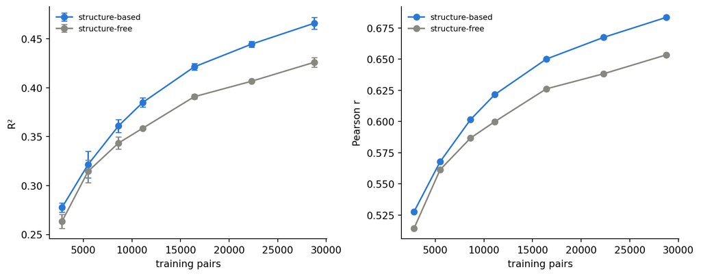

Figure 1: Learning curve on a fixed protein-grouped test set. A curve still rising at the largest training size indicates that more docked data would continue to help; the vertical gap between the two series is the measured value of the docked structure.

Table 3: Learning-curve summary. R2_sd is the spread across repeated subsamples of the same size.

| features | frac | n_train | n_proteins | R2 | R2_sd | Pearson | RMSE |
| --- | --- | --- | --- | --- | --- | --- | --- |
| structure-based | 0.1 | 2809.667 | 1148.000 | 0.278 | 0.005 | 0.528 | 1.295 |
|  | 0.2 | 5489.000 | 2008.667 | 0.322 | 0.014 | 0.568 | 1.255 |
|  | 0.3 | 8612.000 | 2771.000 | 0.361 | 0.007 | 0.602 | 1.218 |
|  | 0.4 | 11110.667 | 3497.333 | 0.385 | 0.005 | 0.622 | 1.195 |
|  | 0.6 | 16414.667 | 4810.333 | 0.421 | 0.004 | 0.650 | 1.159 |
|  | 0.8 | 22302.333 | 6033.333 | 0.444 | 0.003 | 0.668 | 1.135 |
|  | 1.0 | 28767.000 | 7168.000 | 0.466 | 0.006 | 0.684 | 1.113 |
| structure-free | 0.1 | 2809.667 | 1148.000 | 0.264 | 0.007 | 0.514 | 1.308 |
|  | 0.2 | 5489.000 | 2008.667 | 0.314 | 0.012 | 0.561 | 1.261 |
|  | 0.3 | 8612.000 | 2771.000 | 0.343 | 0.006 | 0.587 | 1.234 |
|  | 0.4 | 11110.667 | 3497.333 | 0.359 | 0.001 | 0.600 | 1.220 |
|  | 0.6 | 16414.667 | 4810.333 | 0.391 | 0.002 | 0.626 | 1.189 |
|  | 0.8 | 22302.333 | 6033.333 | 0.407 | 0.001 | 0.638 | 1.174 |
|  | 1.0 | 28767.000 | 7168.000 | 0.426 | 0.005 | 0.654 | 1.154 |

Over the final segment the docked model moves from R² 0.445 at 22,302 pairs to R² 0.466 at 28,767, a slope of **+0.058 R² per doubling** of training data. Averaged over all training sizes the HADDOCK block is worth **+0.025 R²**.

# 5 Phase 2 — structure-free at scale

Docking 1.8 M complexes was not feasible within the project. The alternative was to drop the structure entirely and buy accuracy with data instead: keep every feature derivable from sequence and SMILES alone, and train on the full corpus.

The production model uses:

Table 4: Feature layout of the production model. Total 2935 features.

| block | width | source |
| --- | --- | --- |
| ChemBERTa-77M ligand embedding | 384 | SMILES |
| RDKit descriptors | 226 | SMILES |
| ECFP4 count fingerprint | 1024 | SMILES |
| ESM2-650M protein embedding | 1280 | sequence |
| Amino-acid composition + length | 21 | sequence |

A second variant replaces ESM2-650M with the 80× smaller ESM2-8M (320 dims, 1975 features total) and is trained identically, so any difference between them is attributable to the protein representation alone.

Training used XGBoost with a protein-grouped split, and the inner split used for early stopping holds out the same key as the outer one — a random inner split would let the model tune against proteins it is then tested on.

**Benchmark ligands were removed from training before any model was fitted.** Every training ligand within ECFP4 Tanimoto 0.50 of any benchmark ligand was dropped. Without that gate the benchmark would measure memorisation.

# 6 Benchmark design

Evaluation uses a purpose-built set of 500 protein–ligand pairs over 20 targets, constructed to be hard in the ways that matter:

- **Ligand-novel.** Every benchmark ligand is below ECFP4 Tanimoto 0.50 to anything in training.
- **Temporal.** Every measurement is from 2025 or later and absent from ChEMBL v34 (April 2024), the release most plausibly inside Boltz-2’s training window.
- **Assay-filtered.** Kd and Ki only, at ChEMBL confidence ≥ 8.

**The benchmark is deliberately *not* protein-novel.** `input.csv` covers essentially every well-measured target, so requiring novel proteins would have left only sparsely characterised ones. All 20 targets appear in training with other ligands. This benchmark therefore measures **ranking novel chemistry against an established target** — the realistic screening scenario — and results here must not be described as zero-shot on the target.

A **constant-mean predictor** appears in every error table. It predicts the benchmark average for every pair, and on a set with this label spread it is a genuinely hard baseline. Any RMSE claim that does not clear it is not a result.

## 6.1 Contamination, tool by tool

The temporal gate is what protects the comparison, and it protects every tool equally: no method trained before 2025 can have seen these measurements. Boltz-2 and PLAPT both predate the cutoff, so neither could have memorised them.

The **ligand-similarity gate does not transfer between tools**, and it is worth being explicit about which way that cuts. Removing every training ligand within ECFP4 Tanimoto 0.50 of a benchmark ligand was applied to *Savant’s* training set only — the other tools were trained by other people on other corpora, and may well retain near-neighbours of these benchmark ligands. Savant is therefore held to a stricter novelty standard than anything it is compared against. Any advantage it shows is measured under a handicap, which is the conservative direction for the claims in this report.

# 7 Results

## 7.1 Absolute affinity, and why it is the wrong headline

Table 5: Pooled over all 500 pairs, ignoring which target each belongs to.

| tool | n | pearson | spearman | rmse | r2 | pred_std_ratio |
| --- | --- | --- | --- | --- | --- | --- |
| Savant | 500 | 0.224 | 0.146 | 1.356 | -0.134 | 0.429 |
| Boltz-2 | 496 | 0.412 | 0.393 | 1.388 | -0.193 | 0.750 |
| PRODIGY-LIG | 496 | 0.333 | 0.340 | 1.537 | -0.461 | 1.087 |
| QSAR (per-target) | 458 | 0.089 | 0.050 | 1.733 | -0.797 | 0.663 |
| Tanimoto kNN | 458 | 0.102 | 0.066 | 1.679 | -0.688 | 0.823 |
| Constant baseline | 500 | NaN | NaN | 1.273 | 0.000 | 0.000 |

Boltz-2 leads on pooled correlation. **No tool — Boltz-2 included — beats the constant-mean predictor on RMSE.** That is a property of this benchmark’s difficulty, and it means no absolute-error claim is available to any method here.

A single pooled correlation, however, blends two different abilities. Splitting them apart explains the entire ranking:

Table 6: Between-target r is the correlation of predicted target means against true target means (‘which protein binds tighter’). Within-target r centres both on the target mean first (‘which ligand binds tighter, given the target’).

| tool | between_r | within_r | pooled_r | target_mean_spread |
| --- | --- | --- | --- | --- |
| Savant | 0.091 | 0.436 | 0.224 | 0.478 |
| Boltz-2 | 0.351 | 0.386 | 0.412 | 0.818 |
| PRODIGY-LIG | 0.295 | 0.237 | 0.333 | 1.137 |
| QSAR (per-target) | 0.124 | 0.155 | 0.089 | 0.829 |
| Tanimoto kNN | 0.135 | 0.066 | 0.102 | 1.006 |
| Constant baseline | -0.028 | NaN | NaN | 0.000 |

Savant has the **highest within-target correlation of any tool tested**, and the lowest between-target correlation. It knows chemistry; it does not know which protein is intrinsically the tighter binder. Boltz-2’s pooled advantage comes almost entirely from the between-target term.

Since these two abilities are worth roughly the same on this benchmark (48 % of label variance is between-target, 52 % within), a pooled score is close to an even blend — and a tool excellent at one and blind to the other lands mid-table.

## 7.2 Ranking compounds within a target

This is the lead-optimisation task: given a target, order its candidate compounds. Spearman is computed inside each target and averaged over targets.

Table 7: Within-target Spearman, mean over 20 targets.

|  | n_targets | mean_spearman | median_spearman | n_positive |
| --- | --- | --- | --- | --- |
| Savant | 20 | 0.281 | 0.269 | 16 |
| Boltz-2 | 20 | 0.228 | 0.242 | 15 |
| PRODIGY-LIG | 20 | 0.233 | 0.196 | 15 |
| QSAR (per-target) | 18 | 0.127 | 0.226 | 12 |
| Tanimoto kNN | 18 | 0.031 | 0.002 | 9 |

Table 8: Paired against Boltz-2, resampling targets. A confidence interval spanning zero means parity, whatever the point estimate.

| tool | n_groups | mean_diff | ci_low | ci_high | P_better | wins | wilcoxon_p | sign_test_p |
| --- | --- | --- | --- | --- | --- | --- | --- | --- |
| Savant | 20 | 0.053 | -0.058 | 0.164 | 0.832 | 10 | 0.571 | 1.000 |
| PRODIGY-LIG | 20 | 0.005 | -0.144 | 0.176 | 0.532 | 9 | 0.869 | 0.824 |
| QSAR (per-target) | 20 | NaN | NaN | NaN | 0.012 | 8 | 0.523 | 0.815 |
| Tanimoto kNN | 20 | NaN | NaN | NaN | 0.000 | 5 | 0.074 | 0.096 |

Savant leads numerically. The paired difference against Boltz-2 does **not** reach significance, so the defensible claim is **parity with a favourable point estimate**, not superiority.

## 7.3 Selectivity across a target panel

86 benchmark ligands were measured against 2–4 proteins each — the carbonic anhydrase isoform panel (CA1/CA2/CA9/CA12), the vasopressin V1a/V2 pair, and others. Predicting which isoform a compound prefers is a real design objective.

The raw version of this question is largely answerable from base rates: if CA2 binds most things more tightly than CA1, “CA2 wins” is usually right without looking at the compound at all. A predictor knowing only each target’s mean scores ≈ 0.88 on the raw metric. The **corrected** metric removes that by centring both truth and prediction on the target mean, asking whether *this* compound prefers CA9 more than a typical compound does.

Table 9: Base-rate-corrected selectivity: sign accuracy over protein-pairs with a corrected gap of at least 0.5 pKd. Chance is 0.50.

|  | n_corrected | corrected_accuracy | corrected_ci_halfwidth | corrected_beats_chance |
| --- | --- | --- | --- | --- |
| Savant | 82 | 0.622 | 0.105 | True |
| Boltz-2 | 82 | 0.573 | 0.107 | False |
| PRODIGY-LIG | 82 | 0.500 | 0.108 | False |
| QSAR (per-target) | 82 | 0.537 | 0.108 | False |
| Tanimoto kNN | 82 | 0.427 | 0.107 | False |

**Savant is the only tool whose interval clears chance.** Boltz-2, PRODIGY-LIG, per-target QSAR and Tanimoto kNN do not. Paired directly against Boltz-2 the advantage is again not significant (Table 10), so the claim is “the only tool demonstrably above chance”, not “better than Boltz-2”.

Table 10: Corrected selectivity, paired against Boltz-2 on identical protein-pairs, cluster-bootstrapped by ligand.

| tool | n_pairs | n_ligands | mean_diff | ci_low | ci_high | P_better | wins | losses | mcnemar_p |
| --- | --- | --- | --- | --- | --- | --- | --- | --- | --- |
| Savant | 82 | 51 | 0.049 | -0.096 | 0.185 | 0.717 | 18 | 14 | 0.597 |
| PRODIGY-LIG | 82 | 51 | -0.073 | -0.275 | 0.132 | 0.219 | 22 | 28 | 0.480 |
| QSAR (per-target) | 82 | 51 | -0.037 | -0.176 | 0.091 | 0.244 | 18 | 21 | 0.749 |
| Tanimoto kNN | 82 | 51 | -0.146 | -0.281 | 0.000 | 0.018 | 12 | 24 | 0.065 |

## 7.4 Against models trained on the target itself

Savant and Boltz-2 are both *general* models: one set of weights covering every protein. But the benchmark’s targets appear in training, so a chemist facing one of them would not necessarily reach for a general model at all. They would fit a **local** model on that target’s own previously measured compounds. That is the real competitor in this setting, and it is the comparison that decides whether a general model earns its place.

**QSAR (per-target)** is quantitative structure–activity relationship modelling, the standard workhorse of medicinal chemistry. The idea is simple: for one protein, take every compound already measured against it, describe each compound numerically, and fit a model mapping description to potency. Here each ligand is described by an **ECFP4 count fingerprint** — a 1024-slot tally of the circular atom environments present in the molecule, so two molecules sharing substructures share fingerprint entries — plus six physicochemical descriptors (molecular weight, logP, polar surface area, hydrogen-bond donors and acceptors, rotatable bonds). A separate gradient-boosted tree model is fitted per target, with an internal validation split for early stopping. It knows nothing about proteins; all of its knowledge of the target is implicit in which compounds bound it.

**Tanimoto kNN** is the cruder and older idea, and in lead optimisation it is often hard to beat: *similar molecules bind similarly*. Tanimoto similarity measures fingerprint overlap — shared bits divided by total bits set, so 1.0 is an identical fingerprint and 0.0 shares nothing. For each benchmark compound the five most similar previously-measured compounds for that target are found, and the prediction is their similarity-weighted mean potency. There is no fitted model at all; it is nearest-neighbour lookup in chemical space, and it is what a chemist does implicitly when they say “this looks like our lead series”.

Both were built **on exactly the rows Savant trained on**, filtered to a single target. That matters for fairness: those rows already passed the ECFP4 Tanimoto 0.50 benchmark gate, so the local baselines face the same ligand-novelty standard. Rebuilding them from the raw corpus would have let them train on near-duplicates of benchmark ligands that Savant was forbidden, and the comparison would have been rigged in their favour.

Targets with fewer than 30 prior ligands cannot support a local model at all; those are reported but excluded from the paired comparison.

Table 11: Savant paired against each local baseline and against Boltz-2, over the 18 targets with enough prior data to fit a local model. Computed here for the model of record; the notebook’s own bench_F_vs_local.csv reports whichever variant scored highest, which is not necessarily this one.

| Savant vs | targets | mean difference | ci low | ci high | Savant wins | wilcoxon p |
| --- | --- | --- | --- | --- | --- | --- |
| QSAR (per-target) | 18 | 0.209 | 0.009 | 0.426 | 11 | 0.099 |
| Tanimoto kNN | 18 | 0.305 | 0.078 | 0.540 | 13 | 0.018 |
| Boltz-2 | 18 | 0.053 | -0.079 | 0.184 | 8 | 0.671 |

Savant beats both, with intervals clear of zero. The more informative view is how that advantage depends on how much data the target already has:

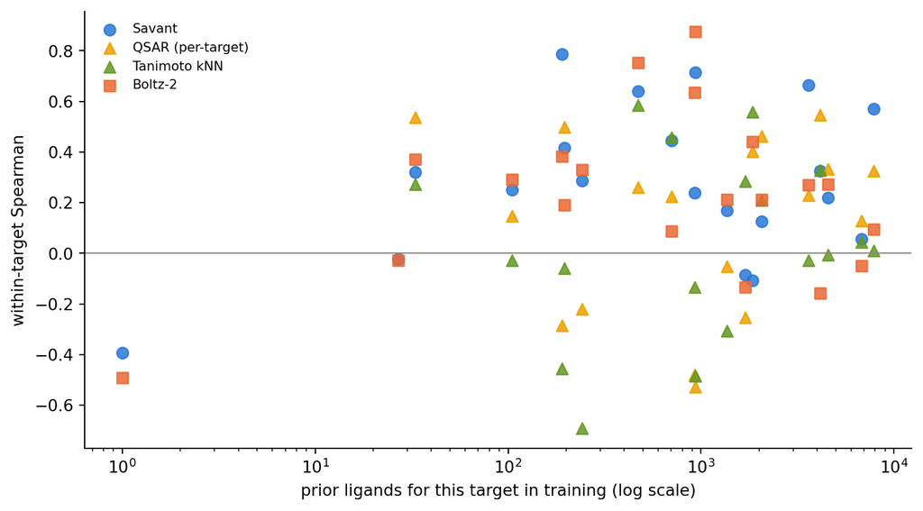

This is the most decision-relevant result in the report. It says when to use Savant and when to build your own model.

## 7.5 Where it works, by target family and chemotype

Table 12: Within-target Spearman by protein family. Families below 20 pairs are reported but not ranked.

| protein_family | n | targets | Savant | Boltz-2 | PRODIGY-LIG | QSAR (per-target) | Tanimoto kNN |
| --- | --- | --- | --- | --- | --- | --- | --- |
| carbonic anhydrase | 130 | 4 | 0.378 | 0.147 | 0.069 | 0.253 | 0.004 |
| GPCR class A | 92 | 3 | 0.374 | 0.574 | 0.276 | -0.352 | -0.308 |
| protein kinase | 79 | 4 | 0.071 | -0.041 | 0.357 | 0.169 | 0.338 |
| transcription factor | 65 | 2 | 0.113 | 0.132 | 0.101 | 0.148 | -0.027 |
| small GTPase / PPI | 48 | 2 | 0.602 | 0.286 | 0.406 | 0.107 | -0.257 |
| other | 31 | 2 | 0.207 | 0.271 | 0.268 | 0.122 | -0.241 |
| isomerase | 23 | 1 | 0.639 | 0.753 | 0.285 | 0.260 | 0.585 |
| ion channel | 17 | 1 | NaN | NaN | NaN | NaN | NaN |
| nuclear receptor | 15 | 1 | NaN | NaN | NaN | NaN | NaN |

Table 13: Within-target Spearman by ligand chemotype (RDKit SMARTS classes).

| ligand_class | n | ligands | Savant | Boltz-2 | PRODIGY-LIG | QSAR (per-target) | Tanimoto kNN |
| --- | --- | --- | --- | --- | --- | --- | --- |
| fused heteroaromatic | 212 | 174 | 0.168 | 0.274 | 0.191 | 0.133 | -0.027 |
| primary sulfonamide | 116 | 41 | 0.215 | -0.110 | 0.090 | 0.042 | -0.217 |
| peptide-like | 67 | 67 | 0.145 | 0.150 | 0.133 | 0.148 | -0.027 |
| macrocycle | 36 | 36 | 0.353 | 0.342 | 0.197 | 0.014 | 0.285 |
| other | 35 | 23 | -0.182 | 0.418 | 0.114 | 0.164 | 0.429 |
| sulfonamide | 22 | 22 | 0.446 | 0.087 | 0.412 | 0.225 | 0.456 |
| halo-aromatic | 10 | 9 | NaN | NaN | NaN | NaN | NaN |
| basic amine | 2 | 1 | NaN | NaN | NaN | NaN | NaN |

Savant is strongest on enzyme isoform panels and protein–protein-interaction targets, where generating a correct pose is exactly the hard part; Boltz-2 leads on classical well-formed pockets such as GPCRs. With 2–4 targets per family this is a hypothesis worth following up, not a finding.